# Generative Adversarial Networks

Generative Adversarial Networks or GANs are a recent unsupervised technique (introduced in 2014 by Ian Goodfellow) to train neural networks to generate plausible data using a zero sum game and then output the entire value - such as an image - in one shot.

In this lecture, I'll be giving a high level view of how GANS work and then build a GAN trained on the MNIST dataset

## How GANS Work:

GANs make use of two neural networks instead of one. The first neural network - called the generator - uses a differentiable function as a genenrator network. The generator takes some random noise as input and transforms it to have a recognizable structure such as a realistic image

[figure not shown]

### How do you train the Generator to do this?

The generator is trained differently from a normal supervised model. It's just shown a bunch of images and told to make more images that come from the same probability distribution. This is where a second neural network, called the discriminator, comes in which learns to guide the generator.

The discriminator is just a regular neural network classifier. During the training process the discriminator is shown real images from the training data half the time and fake images from the generator the other half. The discrimanor is trained to output the probability that the input is real so it tries to assign a probability near 1 to real images and a probability near 0 to fake images. They both get better over time

[figure not shown]

Ian Goodfellow's orignal paper talks about the generator and discrinimator playing the following two player min max game:

[figure not shown]

Two optimization algorithms are run simultaneously each minimizing one of the network’s cost with respect to its parameters.

### How do we achieve this equilibrium?

The generator takes random values Z and maps them to output values X. Wherever the generator maps more values of Z, the probability distribution over X represented by the model becomes denser . The discriminator outputs high values wherever the density of real data is greater than the density of generated data. The generator, in simple words, moves its samples into areas where the model distribution is not yet dense enough.

Eventually, the generator’s distribution matches the real distribution and the discriminator has to output a probability of one half everywhere because every point is equally likely to be generated by the real dataset as to be generated by the model because the two densities are now equal as can be seen from the image above (Again, taken from Ian Goodfellow’s original paper on GANs)

[figure not shown]

## A Simple GAN Model

All the code in this notebook is in python. I used tensorflow instead of keras because I felt like it was simpler implementing a GAN using tensorflow

```python
%matplotlib inline
import numpy as np
import tensorflow as tf
import matplotlib.pyplot as plt

from tensorflow.examples.tutorials.mnist import input_data
mnist = input_data.read_data_sets('MNIST_data')
```

```
Extracting MNIST_data/train-images-idx3-ubyte.gz
Extracting MNIST_data/train-labels-idx1-ubyte.gz
Extracting MNIST_data/t10k-images-idx3-ubyte.gz
Extracting MNIST_data/t10k-labels-idx1-ubyte.gz
```

### Defining the Generator and Discriminator

```python
def model_inputs(real_dim, z_dim):
    real = tf.placeholder(tf.float32, (None, real_dim), name='input_real')
    z = tf.placeholder(tf.float32, (None, z_dim), name='input_z')

    return real, z
```

```python
def generator(z, out_dim, reuse=False):
    with tf.variable_scope('generator', reuse=reuse):
        h1 = tf.layers.dense(z, 128, activation=None)
        h1 = tf.maximum(0.01 * h1, h1)

        logits = tf.layers.dense(h1, out_dim, activation=None)
        out = tf.tanh(logits)

        return out
```

```python
def discriminator(x, reuse=False):
    with tf.variable_scope('discriminator', reuse=reuse):
        h1 = tf.layers.dense(x, 128, activation=None)
        h1 = tf.maximum(0.01 * h1, h1)

        logits = tf.layers.dense(h1, 1, activation=None)
        out = tf.sigmoid(logits)

        return out, logits
```

```python
input_size = 784
z_size = 100
```

```python
tf.reset_default_graph()
input_real, input_z = model_inputs(input_size, z_size)
g_model = generator(input_z, input_size)
d_model_real, d_logits_real = discriminator(input_real)
d_model_fake, d_logits_fake = discriminator(g_model, reuse=True)
```

### Defining Losses and Optimizers

```python
d_loss_real = tf.reduce_mean(tf.nn.sigmoid_cross_entropy_with_logits(logits=d_logits_real,
                                                                     labels=tf.ones_like(d_logits_real)))

d_loss_fake = tf.reduce_mean(tf.nn.sigmoid_cross_entropy_with_logits(logits=d_logits_fake,
                                                                     labels=tf.zeros_like(d_logits_real)))
d_loss = d_loss_real + d_loss_fake

g_loss = tf.reduce_mean(tf.nn.sigmoid_cross_entropy_with_logits(logits=d_logits_fake,
                                                                labels=tf.ones_like(d_logits_fake)))
```

```python
learning_rate = 0.002

t_vars = tf.trainable_variables()
g_vars = [var for var in t_vars if var.name.startswith('generator')]
d_vars = [var for var in t_vars if var.name.startswith('discriminator')]

d_train_opt = tf.train.AdamOptimizer(learning_rate).minimize(d_loss, var_list=d_vars)
g_train_opt = tf.train.AdamOptimizer(learning_rate).minimize(g_loss, var_list=g_vars)
```

### Training the GAN

```
Epoch 1
Epoch 11
Epoch 21
Epoch 31
Epoch 41
Epoch 51
```

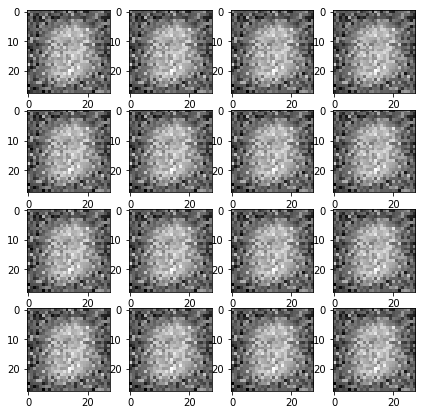

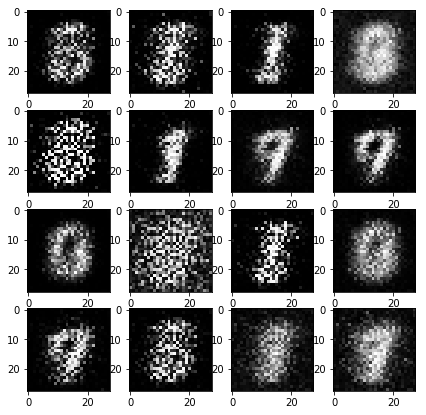

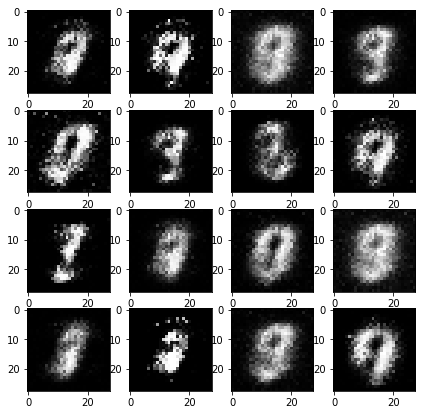

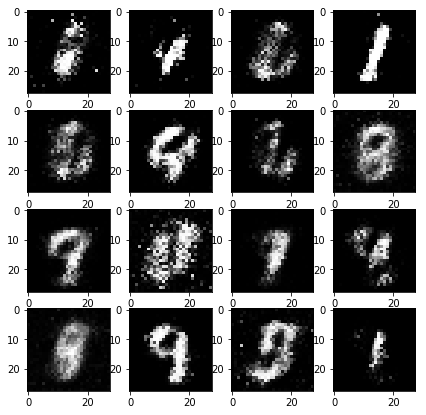

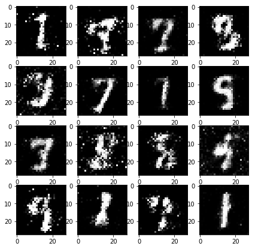

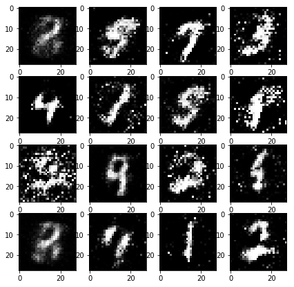

```python
batch_size = 100
epochs = 51
samples = []
with tf.Session() as sess:
    sess.run(tf.global_variables_initializer())
    for e in range(epochs):
        for stuff in range(mnist.train.num_examples//batch_size):
            batch = mnist.train.next_batch(batch_size)

            batch_images = batch[0].reshape((batch_size, 784))
            batch_images = batch_images*2 - 1

            batch_z = np.random.uniform(-1, 1, size=(batch_size, z_size))

            trash = sess.run(d_train_opt, feed_dict={input_real: batch_images, input_z: batch_z})
            trash2 = sess.run(g_train_opt, feed_dict={input_z: batch_z})

        if e%10 == 0:
            print("Epoch {}".format(e+1))

        sample_z = np.random.uniform(-1, 1, size=(16, z_size))
        gen_samples = sess.run(
                       generator(input_z, input_size, reuse=True),
                       feed_dict={input_z: sample_z})
        samples.append(gen_samples)

        if e%10 == 0:
            trash, axes = plt.subplots(figsize=(7,7), nrows=4, ncols=4)
            for ax, img in zip(axes.flatten(), samples[e]):
                im = ax.imshow(img.reshape((28,28)), cmap='Greys_r')
```

### GAN Resources

Here are some resources that I went through while compiling this notebook:

- The original [paper](https://arxiv.org/pdf/1406.2661.pdf) written by Ian Goodfellow in 2014.
- Siraj Raval's [video tutorial](https://www.youtube.com/watch?v=-E2N1kQc8MM) on GANs (Really fun video)
- This other [video](https://www.youtube.com/watch?v=deyOX6Mt_As) on GANS by Siraj Raval (Another fun video)
- Ian Godfellow's [keynote](https://channel9.msdn.com/Events/Neural-Information-Processing-Systems-Conference/Neural-Information-Processing-Systems-Conference-NIPS-2016/Generative-Adversarial-Networks)
- This [notebook](https://github.com/gazay/dlnd-face-generation/blob/master/dlnd_face_generation.ipynb) which was also a huge inspiration to the code I wrote. One big difference is that they used a a DCGAN model which is basically a GAN where the generator and discriminator have convolutional layers. This helps the generator learn added complexities of the images and produces better result but takes a very long time to train.

### Applications of GANS

Cool Applications of GANS:

- [Generative Adversarial Text to Image Synthesis](https://github.com/paarthneekhara/text-to-image)
- [Image super-resolution through deep learning](https://github.com/david-gpu/srez)
- [Medical Image Synthesis with Context-Aware Generative Adversarial Networks](https://arxiv.org/abs/1612.05362)
- [Deep Convolutional Generative Adversarial Networks (DCGAN)](https://github.com/Newmu/dcgan_code)
- [Unpaired Image-to-Image Translation using Cycle-Consistent Adversarial Networks (CycleGAN)](https://github.com/junyanz/CycleGAN)
- [Image-to-image translation with conditional adversarial nets (pix2pix)](https://github.com/phillipi/pix2pix)
- [Τensorflow implementation of Deep Convolutional Generative Adversarial Networks (DCGAN)](https://github.com/carpedm20/DCGAN-tensorflow)
- [Generative Visual Manipulation on the Natural Image Manifold (iGAN)](https://github.com/junyanz/iGAN)
- [Neural Photo Editing with Introspective Adversarial Networks](https://github.com/ajbrock/Neural-Photo-Editor)